# 探索性資料分析與資料視覺化

沈辰禧，台灣大學商研碩士

2018年8月

探索性資料分析一直是商業分析中最普遍的一個流程，而好的EDA也是進階分析、建模十分仰賴的一個關鍵步驟。在這個案例中，我們透過食品供應商的銷售資料，讓各位熟悉「發問、轉換、再發問」的過程，掌握資料的型態之外，也能為企業提供初步的建議。

## 資料輸入與前處理

讀取資料以及需要的library

```r
library(tidyverse)
library(knitr)

SalesTable <- read_csv('SalesTable.csv')
ClientTable <- read_csv('ClientTable.csv')
ProductTable <- read_csv('ProductTable.csv')
```

```r
SalesTableNew <- SalesTable %>%
  inner_join(ClientTable, by = 'Client_ID') %>%
  inner_join(ProductTable, by = 'Product_ID')

kable(SalesTableNew[1:10,])
```

| Agency | Product_ID | Client_ID | Sales_Amount | Sales | Client_Name | Product_Name |
| --- | --- | --- | --- | --- | --- | --- |
| 101 | 1004 | 2003 | 465 | 78971 | CC | D |
| 101 | 1007 | 2003 | 182 | 23053 | CC | G |
| 101 | 1008 | 2003 | 757 | 61897 | CC | H |
| 101 | 1016 | 2003 | 714 | 69885 | CC | P |
| 101 | 1017 | 2003 | 321 | 37015 | CC | Q |
| 101 | 1018 | 2003 | 56 | 6141 | CC | R |
| 101 | 1002 | 2003 | 541 | 54350 | CC | B |
| 101 | 1004 | 2003 | 475 | 56077 | CC | D |
| 101 | 1007 | 2003 | 222 | 40973 | CC | G |
| 101 | 1008 | 2003 | 1868 | 208044 | CC | H |

在這邊可以發現，各種編號都被讀成`int`，將所有`Agency`、`Product_ID`和`Client_ID`都轉為`factor`類別，以利後續的分析

```r
SalesTableNew$Agency <- as.factor(SalesTableNew$Agency)
SalesTableNew$Product_ID <- as.factor(SalesTableNew$Product_ID)
SalesTableNew$Client_ID <- as.factor(SalesTableNew$Client_ID)
```

## 開始發問及產出觀點

### 銷售量、價格的關係

先整理出一張新的表，計算出商品單價

```r
SalesTablePrice <- SalesTableNew %>%
  mutate( Unit_Price = Sales / Sales_Amount)
```

#### 單價和銷售量

銷售量多集中在150元以下的商品，150元以上的商品不僅交易筆數少，也鮮少創造出500單位以上的銷售量。

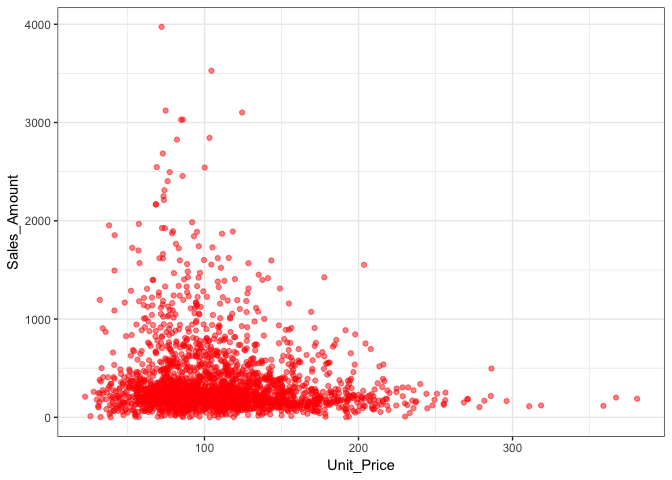

```r
ggplot(data = SalesTablePrice,
             aes( x = Unit_Price,
                  y = Sales_Amount))+
  geom_point(color = 'red',
             alpha = 0.5) + theme_bw()
```

### 不同客戶間的“銷售模式”有何差異

- 用boxplot看出各個客戶銷售的分配(distribution)

可以看出，LL平均而言，每次的銷售額最高；FF、GG和KK也高於其他廠商；但CC有幾次較高的銷售紀錄。

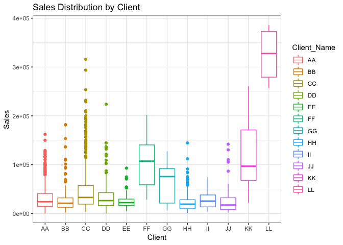

```r
ggplot(SalesTableNew)+geom_boxplot( aes( x = factor(Client_Name),
                                         y = Sales,
                                         colour = Client_Name))+
  labs( x = 'Client',
        title = 'Sales Distribution by Client') + theme_bw()
```

- 用bar chart看出過去一個月的總銷售量

為了讓資料得以順利排序，我們做出一個新的資料表，記錄每個客戶的總銷售。 若是看整個月的銷售，會發現LL的最少，而CC最高，多數的銷售額集中在前幾大的客戶中身上

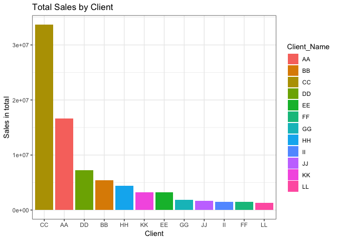

```r
SalesTableSum <- SalesTableNew %>%
  group_by( Client_Name) %>%
  summarise( Sales_Sum = sum(Sales)) %>%
  arrange(desc(Sales_Sum))

ggplot( data = SalesTableSum,
        aes( x = Client_Name,
             y = Sales_Sum,
             fill = Client_Name)) +
  geom_bar( stat = 'identity') +

  scale_x_discrete(limits = SalesTableSum$Client_Name) +

  labs(title = 'Total Sales by Client',
           x = 'Client',
           y = 'Sales in total',
       fill = 'Client_Name') + theme_bw()
```

- 用boxplot看出過去一個月的每位客戶的單價分配

整體而言，對於每一個客戶的單價較一致，對於各客戶言並沒有特別的定價策略。

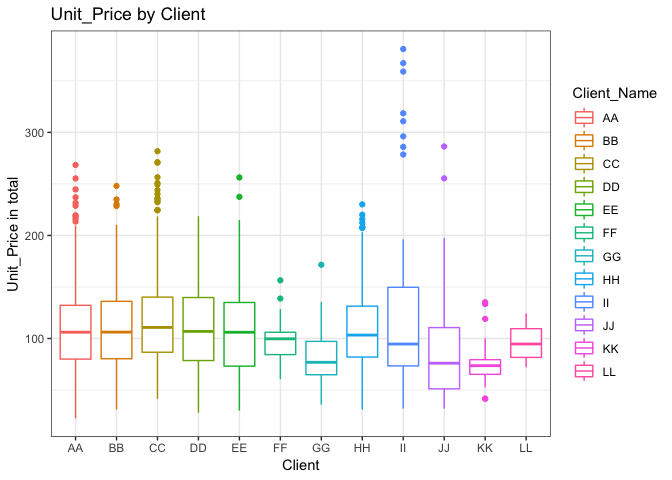

```r
ggplot( data = SalesTablePrice) +
  geom_boxplot(aes( x = as.factor(Client_Name),
             y = Unit_Price,
             colour = Client_Name)) +

  labs(title = 'Unit_Price by Client',
           x = 'Client',
           y = 'Unit_Price in total',
       fill = 'Client_Name') + theme_bw()
```

### 不同產品的銷售模式

- 用boxplot看出各個產品銷售的分配(distribution)

產品H每次的銷售額最高，變異也較大。

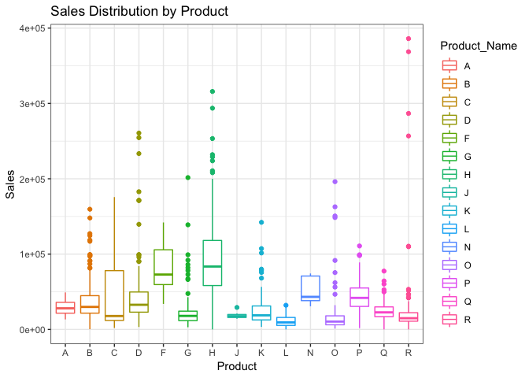

```r
ggplot( data = SalesTableNew) +
  geom_boxplot(aes( x = Product_Name,
                    y = Sales,
                    colour = Product_Name)) +
  labs( x = 'Product',
        title = 'Sales Distribution by Product') + theme_bw()
```

- 用bar chart看出各出過去一個月的總銷售量

總銷售量集中在產品H身上，

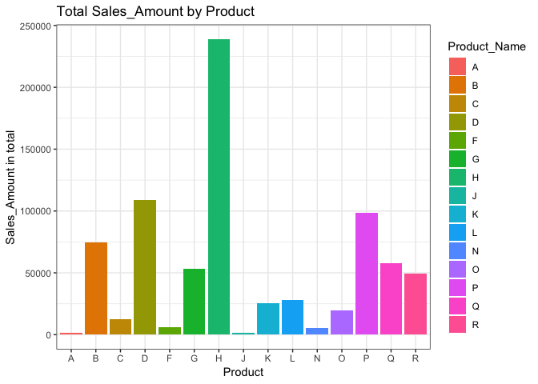

```r
SalesTableAmount <- SalesTableNew %>%
  group_by( Product_Name) %>%
  summarise( Amount_Sum = sum(Sales_Amount)) %>%
  arrange(desc(Amount_Sum))

ggplot( data = SalesTableAmount) +
  geom_bar( aes( x = Product_Name,
             y = Amount_Sum,
             fill = Product_Name),
            stat = 'identity') +

  scale_x_discrete(limits = SalesTableAmount$Client_Name) +

  labs(title = 'Total Sales_Amount by Product',
           x = 'Product',
           y = 'Sales_Amount in total',
       fill = 'Product_Name') + theme_bw()
```

### 合併起來看

整合起來看，我們就能知道每個客戶主要都購買哪些產品，也反映出前四個客戶佔了絕大部分的銷售額

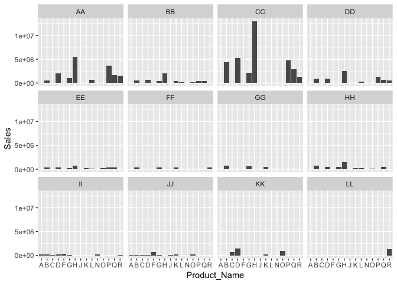

```r
SalesTableClient <- SalesTableNew %>%
  group_by(Client_Name, Product_Name) %>%
  summarise( Sales = sum(Sales))

ggplot( data = SalesTableClient) +
  geom_bar( aes( x = Product_Name,
                 y = Sales),
            stat = 'identity') +
  facet_wrap( ~ Client_Name)
```

- 各經銷商的銷售模式

各經銷商的總銷售也有過度集中的情形

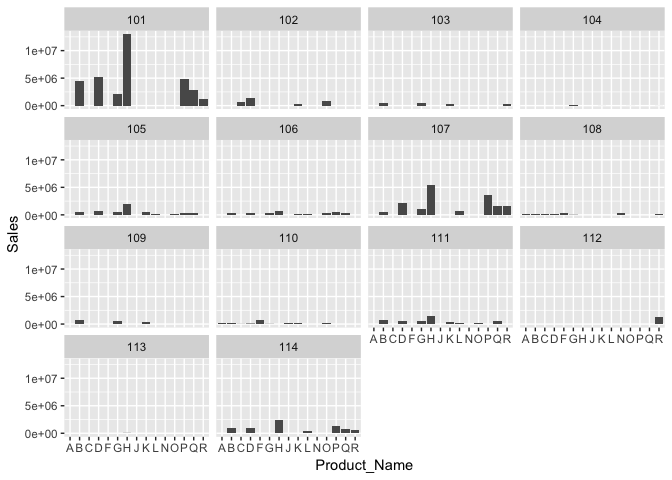

```r
SalesTableAgency <- SalesTableNew %>%
  group_by(Agency, Product_Name) %>%
  summarise( Sales = sum(Sales))

ggplot( data = SalesTableAgency) +
  geom_bar( aes( x = Product_Name,
                 y = Sales),
            stat = 'identity') +
  facet_wrap( ~ Agency)
```

## 客戶及產品銷售資料轉換及呈現

### 客戶間的產品銷售佔比

看到這樣的題目，直覺很容易先想到`Stacked bar`，用分層的長條圖，來呈現佔比和差異。但如果各個factor中含有太多的levels，整個呈現會變得很混亂。

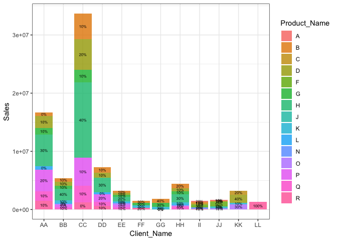

```r
Product <- SalesTableNew %>%
  group_by(Client_Name, Product_Name) %>%
  summarise(Sales = sum(Sales)) %>%
  mutate( Propor = round(Sales / sum(Sales),1) * 100)


ggplot( data = Product) +
  geom_bar( aes( x = Client_Name,
                 y = Sales,
                 fill = Product_Name, label = paste(Propor,'%', sep='')),stat = 'identity', alpha = 0.8) +
  geom_text( aes( x = Client_Name,
                 y = Sales,
                 fill = Product_Name, label = paste(Propor,'%', sep='')),position = position_stack( vjust = 0.5), size = 2) + theme_bw()
```

比較理想的做法是，我們重新去審視這個情境：今天把多個客戶和多個產品擺在同一張圖表呈現，為的就是要能清楚地比較彼此的差異，因此，將數值標準化後，再妥善利用形狀、空間及顏色，就可以得到一張比較直觀卻又不會遺失太多資訊的圖表，這張圖我們主要用`geom_rect()`來完成。

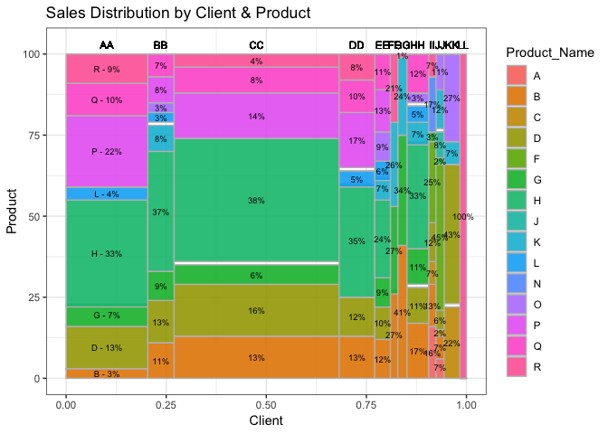

```r
### 將原始數值轉換成圖表需要的極值和比例
Product <- SalesTableNew %>%
  group_by(Client_Name, Product_Name) %>%
  summarise(Sales = sum(Sales))

ClientProductTable <- Product %>%
  spread( key = Product_Name,
          value = Sales) %>%
  data.frame()

Block <- function(ClientProductTable){

  ClientProductTable$x_Percentage <- c()

  ### X軸的比例
  for (i in 1:nrow(ClientProductTable)) {
    ClientProductTable$x_percentage[i] <- rowSums(ClientProductTable[i,-1], na.rm = T) / sum(rowSums(ClientProductTable[,-1], na.rm = T))
  }

  ClientProductTable$x_max <- cumsum(ClientProductTable$x_percentage)
  ClientProductTable$x_min <- ClientProductTable$x_max - ClientProductTable$x_percentage
  ClientProductTable$x_percentage <- NULL

  #Percentage <- ClientProductTable %>%
   # gather( key =  Product_Name,
    #        value = c('Client_Name', 'x_min', 'x_max'),
     #       -c( Client_Name, x_min, x_max))

  Percentage <- ClientProductTable %>%
  gather( key =  Product_Name,
          value = Sales,
          -c(Client_Name, x_min,x_max))#A,B,C,D,F,G,H,J,K,L,N,O,P,Q,R)

  Percentage[,5] <- ifelse(Percentage[,5] %in% NA, 0, Percentage[,5])
  colnames(Percentage)[5] <- 'Sales'

  ### Y軸的比例
  Percentage <- Percentage %>%
    group_by( Client_Name) %>%
    mutate( y_max = round(cumsum(Sales) / sum(Sales) * 100)) %>%
    mutate( y_min = round((y_max - Sales/ sum(Sales) * 100)))


  ### 文字的位置
  Percentage <- Percentage %>%
    mutate( x_text = x_min + (x_max - x_min)/2,
            y_text = y_min + (y_max - y_min)/2)

  Percentage <- Percentage %>%
    group_by( Client_Name) %>%
    mutate( Proportion = round( Sales / sum(Sales),2) * 100)



  ### 作圖
  ggplot(Percentage, aes(ymin = y_min, ymax = y_max,
                      xmin = x_min, xmax = x_max, fill = Product_Name)) +
    geom_rect(colour = I("grey"), alpha = 0.9) +

  geom_text( aes(x = x_text, y = y_text,
                 label = ifelse( Client_Name %in% levels(factor(Client_Name))[1] & Proportion != 0,
                                 paste(Product_Name," - ", Proportion, "%", sep = ""),
                                 ifelse(Proportion != 0, paste( Proportion,"%", sep = ""), paste(NULL)))), size = 2.5) +
    geom_text(aes(x = x_text, y = 103,
                  label = paste(Client_Name)), size = 3) +
    labs( title = 'Sales Distribution by Client & Product',
          x = 'Client',
          y = 'Product') + theme_bw()
}


Block(ClientProductTable)
```

### 資料的取捨

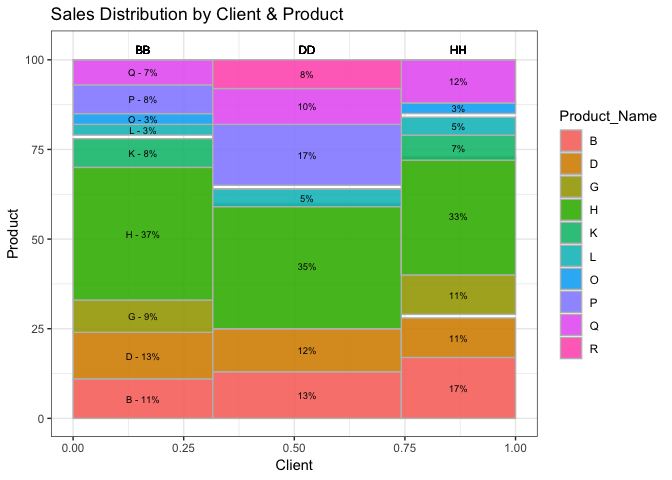

```r
ClientMiddle <- Product %>%
  filter( Client_Name %in% 'BB' | Client_Name %in% 'DD' | Client_Name %in% 'HH')

ClientProductTable <- ClientMiddle %>%
  spread( key = Product_Name,
          value = Sales) %>%
  data.frame()

Block(ClientProductTable)
```

### 產品價格、銷售、銷量、毛利

善用兩軸、形狀和顏色，能夠將這四個維度呈現在同一張圖表中，再搭配水平和鉛直線，切出四個象限之後，又能夠提供多一項資訊，至於要把什麼資訊放在哪個維度，則是資料科學家自己的取捨。

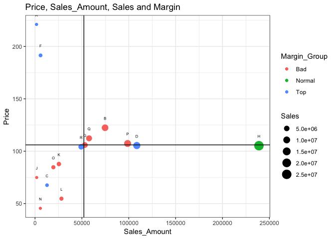

```r
MarginTable <- read_csv('SalesTable_WithCost.csv')
MarginTable$Product_ID <- MarginTable$Product_ID %>% as.factor()
MarginTable$Margin_Rate <- MarginTable$Margin_Rate %>% round(3)

SalesTableMargin <- SalesTableNew %>%
  inner_join(MarginTable, by = 'Product_ID')


ProductSalesTable <- SalesTableMargin %>%
  group_by(Product_Name) %>%
  summarise( Sales = sum(Sales),
             Sales_Amount = sum(Sales_Amount),
             Margin_Rate = mean(Margin_Rate)) %>%
  mutate( Price = Sales/Sales_Amount,
          Margin_Group = ifelse( Margin_Rate > 0.7, 'Top',
                            ifelse( Margin_Rate >= 0.5 & Margin_Rate < 0.7, 'Normal', 'Bad'))) %>%
  arrange(desc(Sales))

ggplot( data = ProductSalesTable,
        aes( x = Sales_Amount,
             y = Price,
             colour = Margin_Group)) +
  geom_point(alpha = 0.9) +
  geom_point( aes(size = Sales))+
  geom_text( aes( label = Product_Name), vjust = -3, size = 2, colour = 'black') +
  geom_vline( aes( xintercept = mean(Sales_Amount))) +
  geom_hline( aes( yintercept = mean(Price))) +

  labs( title = 'Price, Sales_Amount, Sales and Margin') +

  theme_bw()
```

使用`plotly`套件

```r
library(plotly)

MarginPlot <- ggplot( data = ProductSalesTable,
        aes( x = Sales_Amount,
             y = Price,
             colour = Margin_Group)) +
  geom_point(alpha = 0.9) +
  geom_point( aes(size = Sales)) +
  geom_text( aes( label = Product_Name), vjust = -3, size = 2, colour = 'black') +
  geom_vline( aes( xintercept = mean(Sales_Amount))) +
  geom_hline( aes( yintercept = mean(Price))) +

  labs( title = 'Price, Sales_Amount, Sales and Margin') +

  theme_bw()


ggplotly(MarginPlot)
```

[interactive chart not shown]